# Repro Research - Peer-graded Assignment: Course Project 1

Nils Matzner

12 January 2017

## Intro

This is my submission for the Reproducible Research class. It is ordered by the nine tasks from the assignment.

## 1. Code for reading in the dataset and/or processing the data

First, loading my favorite libraries.

```r
library(data.table)
library(ggplot2)
```

Reading table and making a `data.table`.

```r
fdir <- "C:/Users/matznerni/Documents/R/coursera/ProgAssig_Repro1/"
readdata <- read.csv(paste0(fdir, "activity.csv"), colClasses = c("numeric", "Date", "numeric"))
dtna <- as.data.table(readdata)
```

Now, two data.tables are created for later use. One with NAs (`dtna`) and the other (`dt`) without NA values.

```r
dt <- dtna[!is.na(dtna$steps), ]
```

## 2. Histogram of the total number of steps taken each day

The following code sums up the steps by colomn *date* using the `data.table` package.

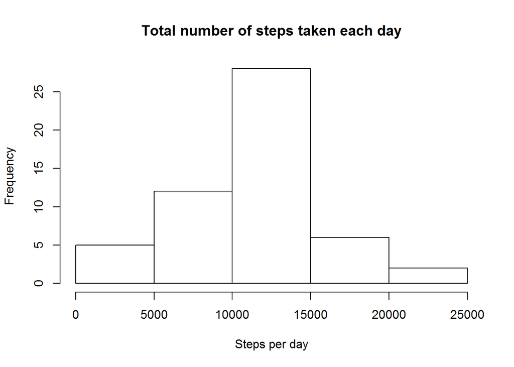

```r
dt.steps <- dt[, sum(steps), by = date]
dt.steps <- dt.steps[, .(V1, date)]
names(dt.steps)[1] <- "daysteps"
hist(dt.steps$daysteps, main = "Total number of steps taken each day", xlab = "Steps per day")
```

## 3. Mean and median number of steps taken each day

```r
stepsmean <- mean(dt.steps$daysteps, na.rm = TRUE)
stepsmedian <- median(dt.steps$daysteps, na.rm = TRUE)
cat(paste0("Mean of steps   ",stepsmean, "\n", "Median of steps ", stepsmedian))
```

```
## Mean of steps   10766.1886792453
## Median of steps 10765
```

## 4. Time series plot of the average number of steps taken

Now, we make a time series of the mean steps which will also be used in the next section.

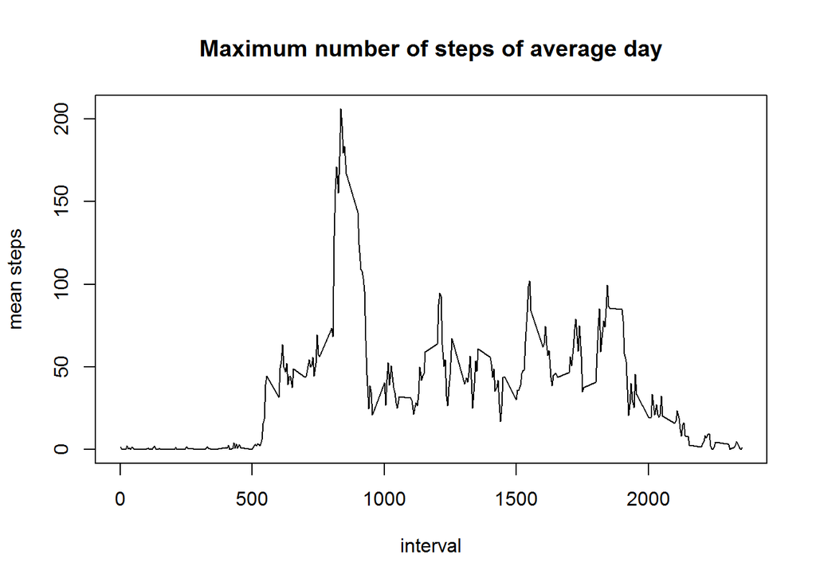

```r
dt.int <- dt[, mean(steps), by = interval]
names(dt.int)[2] <- "mean steps"
plot(dt.int, type = "l", main = "Maximum number of steps of average day")
```

## 5. The 5-minute interval that, on average, contains the maximum number of steps

Here we add a point and text to indicate the interval that contains the abolute maximum of steps.

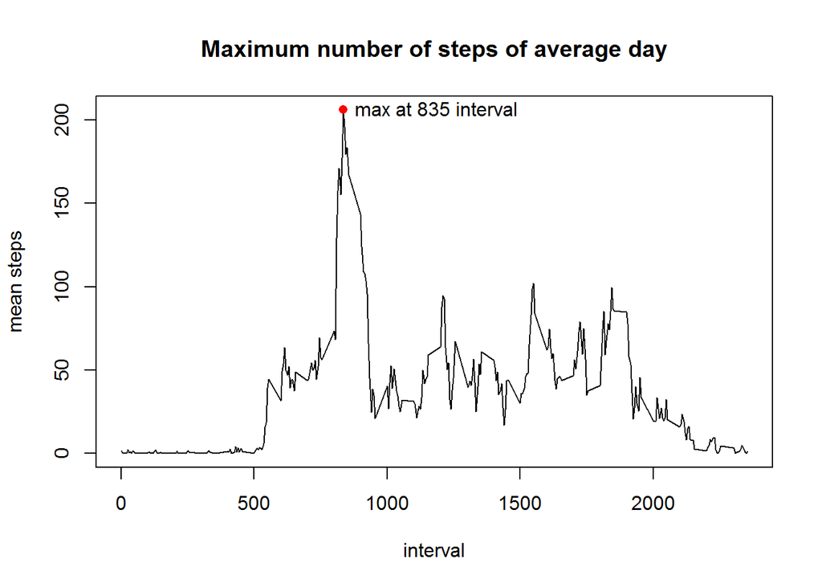

```r
ypos <- max(dt.int$`mean steps`)
xpos <- dt.int[dt.int$`mean steps` == ypos]$interval
plot(dt.int, type = "l", main = "Maximum number of steps of average day")
points(xpos, ypos, pch = 16, col = "Red")
text(xpos, ypos, paste0("max at ", xpos, " interval"), pos = 4)
```

## 6. Code to describe and show a strategy for imputing missing data

No. of NA values in columns of the data.table.

```r
colSums(is.na(dtna))
```

```
##    steps     date interval
##     2304        0        0
```

The following lines will create and fill a data.table with mean values. NAs will be replaced with means.

```r
dtfill <- dtna
dtfill[is.na(dtfill$steps), ]$steps <- dt.int$`mean steps`
```

## 7. Histogram of the total number of steps taken each day after missing values are imputed

The same operations as under no. 2 are reproduced with data including NA values.

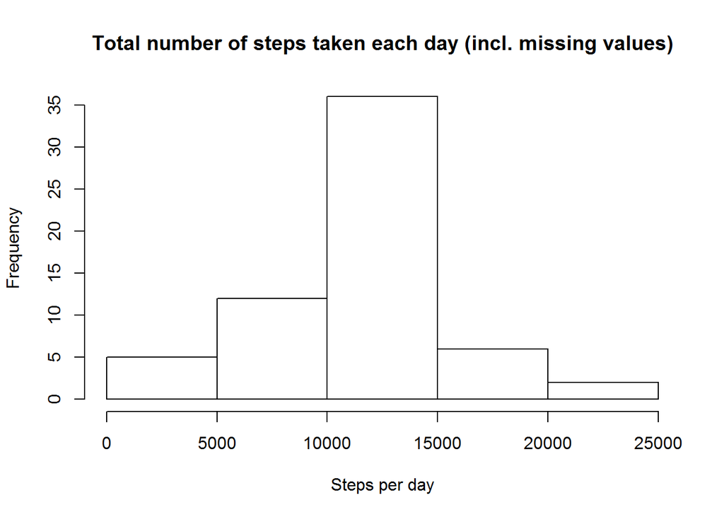

```r
dtfill.steps <- dtfill[, sum(steps), by = date]
dtfill.steps <- dtfill.steps[, .(V1, date)]
names(dtfill.steps)[1] <- "daysteps"
hist(dtfill.steps$daysteps, main = "Total number of steps taken each day (incl. missing values)", xlab = "Steps per day")
```

The data filled with NA values is used to calculate mean and median again. Means and medians of normal and filled data are compared.

```r
stepsmean.fill <- mean(dtfill.steps$daysteps, trim = 1)
stepsmedian.fill <- median(dtfill.steps$daysteps)
cat(paste0("Mean of steps                    ",stepsmean, "\n", "Median of steps                  ", stepsmedian, "\n", "Mean of steps with filled data   ", stepsmean.fill, "\n", "Median of steps with filled data ", stepsmedian.fill))
```

```
## Mean of steps                    10766.1886792453
## Median of steps                  10765
## Mean of steps with filled data   10766.1886792453
## Median of steps with filled data 10766.1886792453
```

## 8. Panel plot comparing the average number of steps taken per 5-minute interval across weekdays and weekends

Weekdays are computated from dates. Then weekday/weekend split the data and allow to caldulate two sets of mean steps. These are combined in one plot (using `ggplot2`, which has been loaded above).

```r
Sys.setlocale("LC_TIME", "English") # In case sys-language is different
```

```
## [1] "English_United States.1252"
```

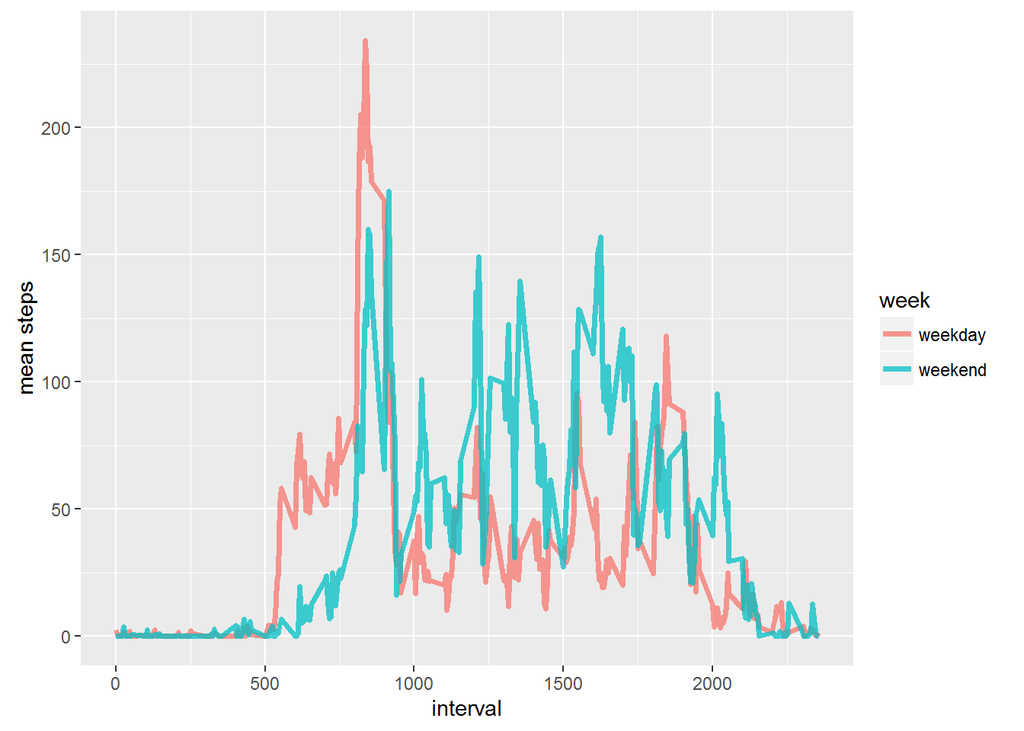

```r
dtweek <- dt[, weekd := as.factor(ifelse(weekdays(dt$date) %in% c("Saturday", "Sunday"), "weekend", "weekday"))]
lweek <- split(dtweek[,.(steps, interval, weekd)], dtweek$weekd)
lweek <- lapply(lweek, function(x){x[, mean(steps), by = interval]})
dtweek <- rbind2(cbind(lweek[[1]], "weekday"), cbind(lweek[[2]], "weekend")) # This could have been more elegant
colnames(dtweek) <- c("interval", "mean steps", "week")
dtweek$week <- as.factor(dtweek$week)
ggplot(dtweek, aes(interval, `mean steps`, color = week)) +
      geom_line(aes(group = week), size = 1.25, alpha = 0.75)
```

## 9. All of the R code needed to reproduce the results (numbers, plots, etc.) in the report

The code and its results are visible above.

*Thanks for reviewing my assignment!*